# Data Privacy Survey

Challenges and needs of privacy-related services for research at Utrecht University

Dorien Huijser, Research Data Management Support, Utrecht University

Neha Moopen, Research Data Management Support, Utrecht University

Version: 2022-08-15

Abstract

In the second quarter of 2022, Utrecht University (UU) Research Data Management Support (RDM Support) sent out a survey among all scientific personnel at UU: the Data Privacy Survey. The aim of this survey was to investigate 1) How UU researchers currently deal with personal data in research, 2) What challenges they run into when handling personal data in research, and 3) How support at UU can improve their services concerning personal data in research. The results show that most researchers know to take into account privacy in their projects. However, there are vast differences in knowledge on this topic, as well as confusion on topics such as data sharing, anonymisation, and the administrative requirements surrounding privacy. Taken together, the survey shows that researchers could benefit from research support that is more visible in the organisation and more hands-on (i.e., advise that is immediately applicable instead of more general). Additionally, more awareness of the most important privacy-related topics, and how to deal with them in research seems desirable, both for newly employed and existing researchers. Finally, many researchers indicate to experience a high administrative burden that is partly caused by privacy-related documentation before starting a project. Finding a way to decrease this burden while still complying with legal and policy regulations will likely help to increase compliance and help researchers focus on performing high-quality research.

# Introduction

Scientific research often includes some form of personal data. The amount of personal data that is processed in research is likely underestimated, as researchers may be unaware of what personal data are or whether they are being collected. With the implementation of the General Data Protection Regulation (GDPR) in 2018, stricter legal requirements apply to handling personal data and its sharing and publication. In our own experience, the number and complexity of questions on handling personal data in scientific research at Utrecht University (UU) is increasing.

Our premise at [Research Data Management Support](https://uu.nl/rdm) (RDM Support) is to assist researchers with any issues surrounding the management of their research data, including research data that contains personal data. To understand how we can best help researchers with their privacy-related questions and needs, we wanted to investigate:

1. To what extent are UU researchers aware of privacy legislation and practices?
2. What data privacy issues do UU researchers typically run into?
3. What support do UU researchers need to handle personal data?

To answer these questions, we set up an online survey and planned one-on-one meetings with a selection of UU researchers. This report describes our methods, results and the future steps that data support at UU can take to improve their services concerning privacy in research.

This survey was part of a larger project at UU, the [Data Privacy Project](https://utrechtuniversity.github.io/dataprivacyproject/)[^1]. This project is a data support effort within UU that aims to provide actionable and FAIR (Findable, Accessible, Interoperable, Reusable) information and tools for researchers to handle personal data in their research.

# Methods

## Survey questions

The Data Privacy Survey was created by the project coordinators (DH, NM) with input from a wide variety of experts, consisting of privacy experts, data managers, data consultants, and IT staff (e.g., information security, research engineering). The survey consisted of 19-23 questions (the exact number differing depending on given answers), which were separated into 5 sections:

1. **About you and your research**: 5 questions about the faculty, department, position, and type of (personal) data the researcher works with.
2. **Measures and documents**: 4-6 questions about researchers’ familiarity and use of privacy-related measures (e.g., processing register, Data Privacy Impact Assessment, encryption, pseudonymisation, etc.), data storage, and informed consent forms.
3. **Data sharing, archiving and publication**: 3-4 questions about researchers’ data sharing and publishing practices.
4. **Finding support**: 3-4 questions about the awareness of several data support channels.
5. **Improving our services**: 4 questions about researchers’ challenges, needs, and suggestions to improve UU’s data privacy support.

The estimated 10 minute duration of the survey in advance proved to be relatively accurate: respondents spent a median of 8.4 minutes on the survey (although there was a very large variation; range: 0.4 minutes - 5.1 days).

## Procedure online survey

The survey was created in Qualtrics and distributed from March 21st, 2022 onwards via several communication channels to reach as many UU researchers as possible:

- An [email](https://utrechtuniversity.github.io/dataprivacyproject/20220321-data-privacy-survey.html) was sent to all academic staff at UU through central communication channels. The reasoning was that this would be the most effective way to reach as many UU researchers as possible - taking for granted that we would likely miss a small part of non-academic personnel also involved in research in some way.
- A mention in several Faculty newsletters.
- Social media messages (e.g., on [Twitter](https://twitter.com/RDMsupportUU/status/1517390979707412481)).
- A [news item](https://intranet.uu.nl/en/news/news-items/survey-better-support-for-handling-privacy-sensitive-data-in-research) on the UU intranet.
- Via data support colleagues, who were asked to point researchers they were in contact with to the survey.

Researchers could decide voluntarily whether they wanted to participate in the survey. All results reported here are from researchers who provided their active consent, worked at Utrecht University and indicated to work with some type of research data.

## Online survey respondents

The survey was filled out by 175 UU researchers. As can be seen in the figure below, we received responses from each UU faculty, but the distribution was not equal: the faculties of Science and Social and Behavioural Sciences were overrepresented, whereas the responses of the Faculty of Geosciences and the Faculty of Medicine were rather low. This can be explained by the mere size of the faculties (e.g., the faculty of Science is UU’s largest faculty), but also by the types of research performed there. For example, research performed at the faculty of Geosciences is largely involved with natural scientific data, rather than data from or relating to humans. The Faculty of Medicine, then, is located at the University Medical Center Utrecht (UMCU) and is not of primary interest for the current survey, which was sent to UU researchers only. A small selection of respondents indicated to work at another part of the organisation, being mainly University College Utrecht and the University Corporate Office.

Most of the survey respondents were relatively early career researchers (PhDs, junior researchers and postdoctoral researchers). We suspect that this is because 1) there simply are more people in these positions than there are in the others, and 2) early-career researchers may experience a greater need for support with respect to handling personal data.

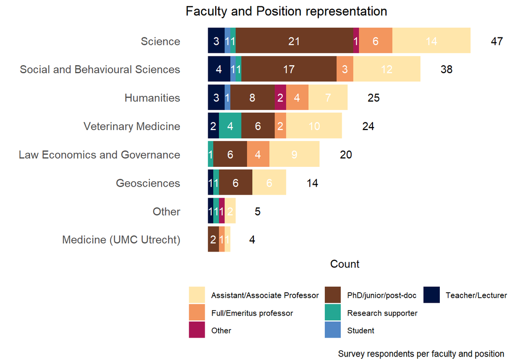

## One-on-one meetings

Besides the online survey, we organised one-on-one meetings with researchers, to hear about their personal experiences, challenges and needs concerning the handling of personal data in their research. Survey respondents could voluntarily leave their email address at the end of the survey to be contacted by us. These meetings were semi-structured and revolved around the following questions:

- What made you leave your email address in the Data Privacy Survey? Related: What are your general experiences in handling personal data in research?
- Which difficulties do you run into when handling personal data?
- What support would you need to help you handle personal data in your research?
- Do you have a concrete need for support at the moment?

Below, the division over faculties can be seen for all interviewees. For privacy reasons, the positions of the interviewees are not displayed here.

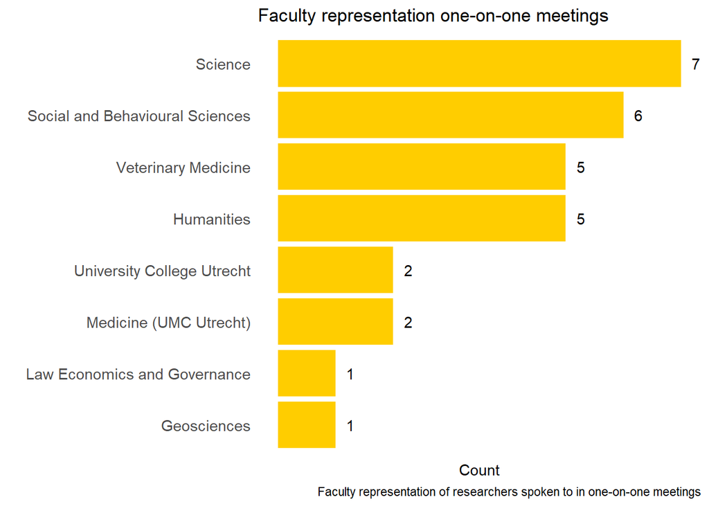

## Analysis

From the raw Qualtrics output, we first cleaned and split the data into different data files (cleaned and closed survey responses, open text responses, email addresses, see the pseudonymise-data.R script for details). Both the open text responses and the notes made during the one-on-one meetings were separately and manually scored to enable the extraction of action points.

Below we report on the descriptive statistics or summaries from most of the survey questions. As we did not formulate hypotheses, no statistical analyses were performed.

## Data and material availability

All survey-related documentation can be found in the [dedicated survey repository](https://github.com/UtrechtUniversity/dataprivacysurvey). It contains:

- The [full survey](https://utrechtuniversity.github.io/dataprivacysurvey/assets/survey-questions-qualtrics.pdf)
- The survey’s [privacy statement](https://utrechtuniversity.github.io/dataprivacysurvey/assets/survey-privacy-statement.pdf)
- The [scripts used to clean the data and write this report](https://github.com/UtrechtUniversity/dataprivacysurvey/tree/main/src)

As the dataset contains personal information (demographic information, open text responses, email addresses, etc.), and no consent was obtained to share those details, we are unable to share them in this repository.

# Results

## Types of research data

### University-wide

To investigate the types of research that was represented in the sample, we asked which types of data, and specifically which types of *personal* data the respondents worked with. Most respondents indicated to use tabular, textual, code and audio data as their primary research data format. In terms of *personal* data types, contact information, demographic information and direct identifiers were most common among the respondents. This can be either because these are the types of personal data that are indeed most common, but possibly also because researchers mostly recognise these types of data as being personal data.

**Types of data used**

| Datatype | Frequency |
| --- | --- |
| Tabular data | 124 (70.9%) |
| Textual data | 106 (60.6%) |
| Code/theoretical models | 60 (34.3%) |
| Audio data | 56 (32%) |
| Video data | 39 (22.3%) |
| Images | 38 (21.7%) |
| Bio-medical samples and data | 28 (16%) |
| Physiological measurements | 27 (15.4%) |
| Geographical data | 25 (14.3%) |
| Physical samples | 11 (6.3%) |
| Other | 8 (4.6%) |

**Types of *personal* data used**

| Personal Datatype | Frequency |
| --- | --- |
| Demographic information | 102 (58.3%) |
| Contact information | 81 (46.3%) |
| Direct identifiers | 66 (37.7%) |
| Sensitive demographic information | 35 (20%) |
| Human behaviour | 32 (18.3%) |
| Derived personal data | 30 (17.1%) |
| Health/physical information | 25 (14.3%) |
| None | 18 (10.3%) |
| Other | 11 (6.3%) |
| Sensitive direct identifiers | 9 (5.1%) |

When comparing faculties, it appears that most personal data is processed in the faculties of Social and Behavioural Sciences (FSBS), although the faculties of Science and Veterinary Medicine also seem to process quite some personal data. In the tabs, we look further into the types of (personal) data processed within each faculty.

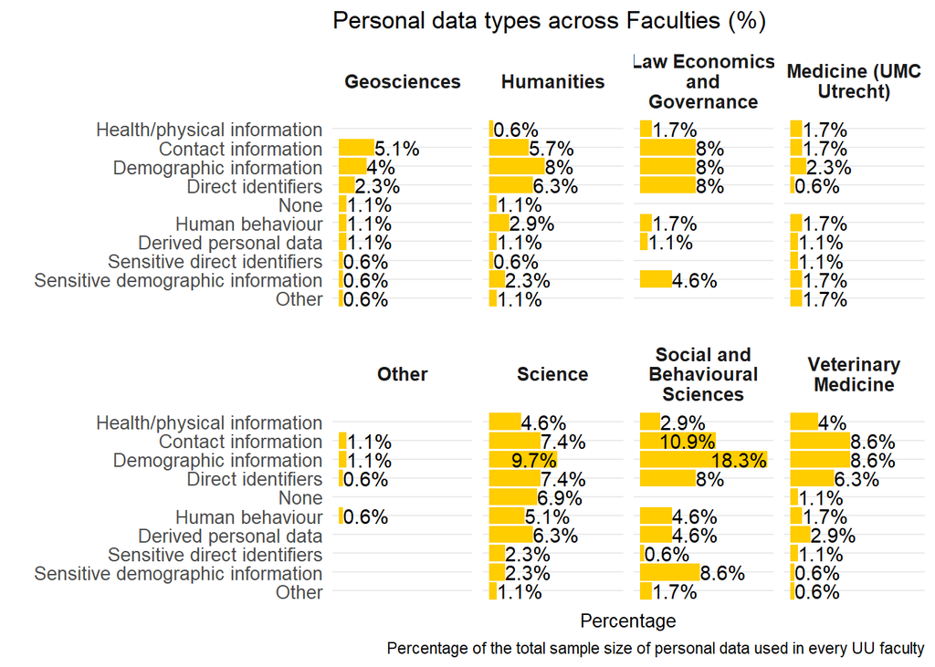

### FSBS

As with the university-wide data, researchers from the faculty of Social and Behavioural Sciences (FSBS) indicated that they also most often used tabular data, textual data and code/theoretical models in their research. The same goes for the types of *personal* data: demographic and contact information are most often used. Interestingly, sensitive demographic information is used much more relative to the UU-wide responses.

**Types of data used**

| Datatype | Frequency |
| --- | --- |
| Tabular data | 32 (18.3%) |
| Textual data | 17 (9.7%) |
| Code/theoretical models | 12 (6.9%) |
| Audio data | 12 (6.9%) |
| Video data | 10 (5.7%) |
| Physiological measurements | 7 (4%) |
| Geographical data | 6 (3.4%) |
| Other | 4 (2.3%) |
| Bio-medical samples and data | 4 (2.3%) |
| Images | 3 (1.7%) |

**Types of *personal* data used**

| Personal Datatype | Frequency |
| --- | --- |
| Demographic information | 32 (18.3%) |
| Contact information | 19 (10.9%) |
| Sensitive demographic information | 15 (8.6%) |
| Direct identifiers | 14 (8%) |
| Human behaviour | 8 (4.6%) |
| Derived personal data | 8 (4.6%) |
| Health/physical information | 5 (2.9%) |
| Other | 3 (1.7%) |
| Sensitive direct identifiers | 1 (0.6%) |

When comparing the types of personal data across departments of the faculty, the departments of Sociology and Cultural Anthropology seem to process the least amount of personal data - although these departments may also simply be underrepresented in the survey sample. Most other departments process quite some personal data, as can be expected from a faculty of which the research focuses almost exclusively on humans.

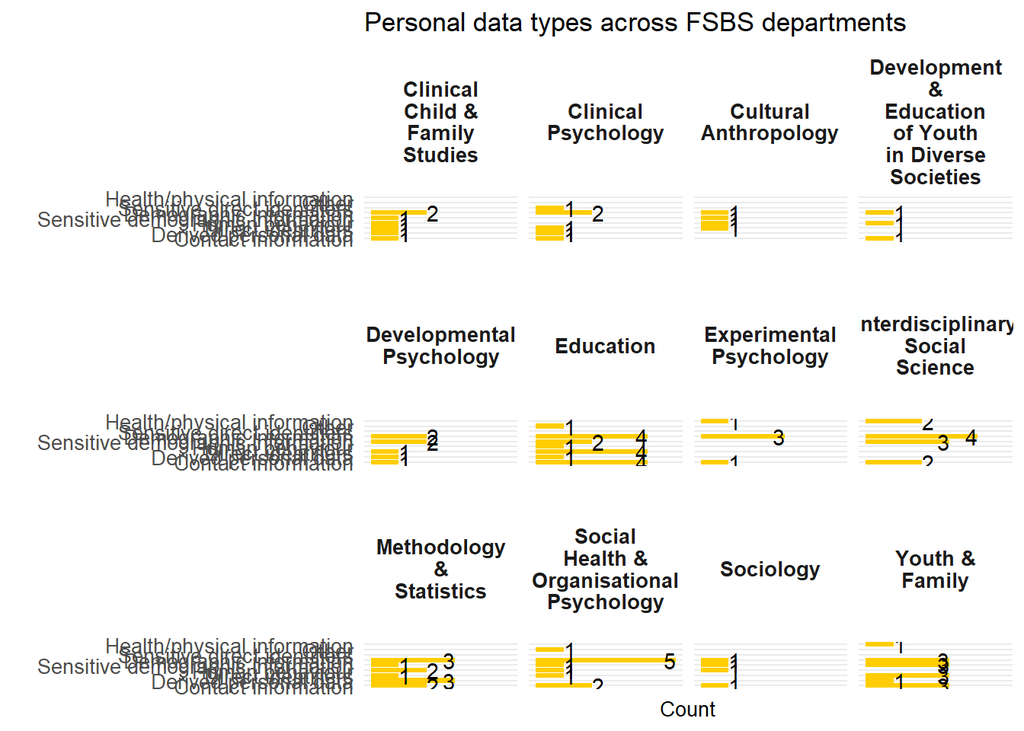

### Humanities

As with the university-wide data, researchers from the faculty of Humanities indicated that they also most frequently used tabular data, textual data and audio data in their research. The same goes for the types of *personal* data: the same top-3 types are present here as in the entire university (demographic information, contact information, direct identifiers).

**Types of data used**

| Datatype | Frequency |
| --- | --- |
| Textual data | 18 (10.3%) |
| Tabular data | 13 (7.4%) |
| Audio data | 12 (6.9%) |
| Video data | 6 (3.4%) |
| Images | 5 (2.9%) |
| Code/theoretical models | 4 (2.3%) |
| Physiological measurements | 2 (1.1%) |
| Bio-medical samples and data | 2 (1.1%) |

**Types of *personal* data used**

| Personal Datatype | Frequency |
| --- | --- |
| Demographic information | 14 (8%) |
| Direct identifiers | 11 (6.3%) |
| Contact information | 10 (5.7%) |
| Human behaviour | 5 (2.9%) |
| Sensitive demographic information | 4 (2.3%) |
| Other | 2 (1.1%) |
| None | 2 (1.1%) |
| Derived personal data | 2 (1.1%) |
| Sensitive direct identifiers | 1 (0.6%) |
| Health/physical information | 1 (0.6%) |

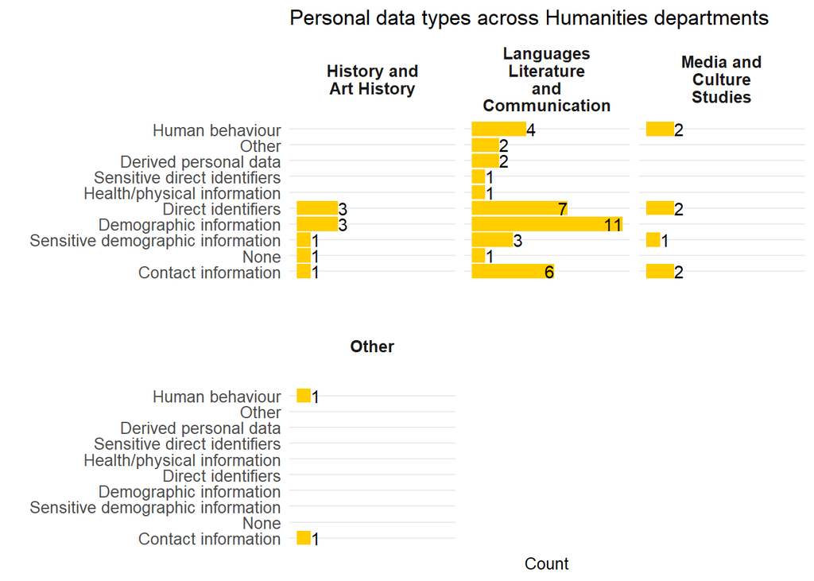

### Veterinary Medicine

When comparing the types of data that researchers at the Faculty of Veterinary Medicine work with, it is clear that researchers at this faculty work with slightly different types of data, i.e. biological and physiological data are more common among these researchers. Despite this, the most frequent types of personal data do correspond well to the university-wide numbers: demographic information, direct identifiers and contact information are also the most common types of personal data researchers at this faculty seem to deal with.

**Types of data used**

| Datatype | Frequency |
| --- | --- |
| Tabular data | 19 (10.9%) |
| Bio-medical samples and data | 13 (7.4%) |
| Textual data | 12 (6.9%) |
| Physiological measurements | 12 (6.9%) |
| Images | 10 (5.7%) |
| Code/theoretical models | 10 (5.7%) |
| Video data | 9 (5.1%) |
| Geographical data | 6 (3.4%) |
| Audio data | 4 (2.3%) |
| Physical samples | 3 (1.7%) |
| Other | 1 (0.6%) |

**Types of *personal* data used**

| Personal Datatype | Frequency |
| --- | --- |
| Demographic information | 15 (8.6%) |
| Contact information | 15 (8.6%) |
| Direct identifiers | 11 (6.3%) |
| Health/physical information | 7 (4%) |
| Derived personal data | 5 (2.9%) |
| Human behaviour | 3 (1.7%) |
| Sensitive direct identifiers | 2 (1.1%) |
| None | 2 (1.1%) |
| Sensitive demographic information | 1 (0.6%) |
| Other | 1 (0.6%) |

When looking at each department separately, it is clear that researchers in the department of Population Health Sciences process the large majority of the personal data within the faculty. Of course, it may also be possible that this department was simply more represented in the survey than the other departments.

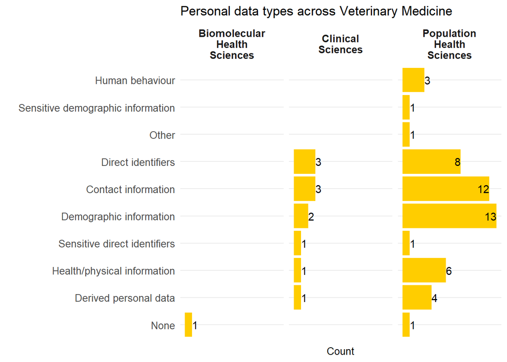

### LEG

As with the university-wide data, researchers from the faculty of Law, Economics and Governance (LEG) indicated that they also most frequently used tabular data, textual data and audio data in their research. The same goes for the types of *personal* data: the same top-3 types are present here as in the entire university (demographic information, contact information, direct identifiers).

**Types of data used**

| Datatype | Frequency |
| --- | --- |
| Textual data | 17 (9.7%) |
| Tabular data | 13 (7.4%) |
| Audio data | 12 (6.9%) |
| Images | 3 (1.7%) |
| Video data | 2 (1.1%) |
| Geographical data | 2 (1.1%) |
| Code/theoretical models | 1 (0.6%) |

**Types of *personal* data used**

| Personal Datatype | Frequency |
| --- | --- |
| Direct identifiers | 14 (8%) |
| Demographic information | 14 (8%) |
| Contact information | 14 (8%) |
| Sensitive demographic information | 8 (4.6%) |
| Human behaviour | 3 (1.7%) |
| Health/physical information | 3 (1.7%) |
| Derived personal data | 2 (1.1%) |

When looking at the different departments within the faculty, researchers in the department of Governance seem to process personal data the most often, followed by the department of Law. Of course, it is possible that the other departments process more personal data than the respondents indicated.

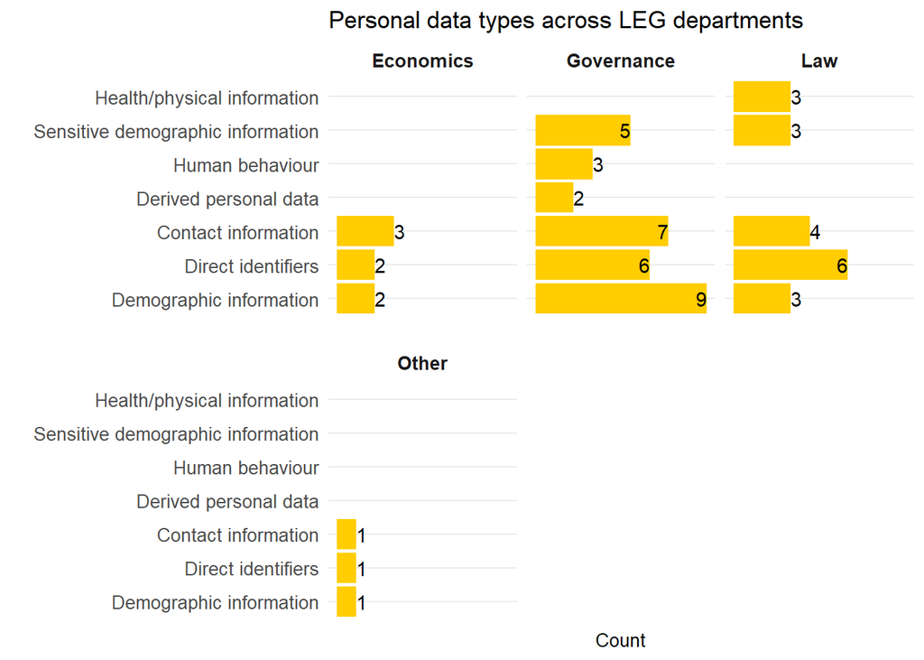

### Geo

As with the university-wide data, researchers from the faculty of Geosciences indicated that they also most frequently used textual and tabular data. However, in contrast to the university-wide data, they are followed by geographical data and code/theoretical models. This is to be expected considering the faculty. In terms of *personal* data, however, the same top-3 types are present here as in the entire university (demographic information, contact information, direct identifiers).

**Types of data used**

| Datatype | Frequency |
| --- | --- |
| Textual data | 11 (6.3%) |
| Tabular data | 10 (5.7%) |
| Geographical data | 7 (4%) |
| Code/theoretical models | 7 (4%) |
| Audio data | 4 (2.3%) |
| Video data | 2 (1.1%) |
| Physical samples | 2 (1.1%) |
| Images | 2 (1.1%) |

**Types of *personal* data used**

| Personal Datatype | Frequency |
| --- | --- |
| Contact information | 9 (5.1%) |
| Demographic information | 7 (4%) |
| Direct identifiers | 4 (2.3%) |
| None | 2 (1.1%) |
| Human behaviour | 2 (1.1%) |
| Derived personal data | 2 (1.1%) |
| Sensitive direct identifiers | 1 (0.6%) |
| Sensitive demographic information | 1 (0.6%) |
| Other | 1 (0.6%) |

When comparing departments, it becomes immediately clear that most personal data seems to be processed in the department of Sustainable Development, and some also in the Human Geography and Spatial Planning department. This makes sense, as the research performed at the third department (Earth sciences) usually does not focus on human behaviour and thus does not involve much personal data, if any.

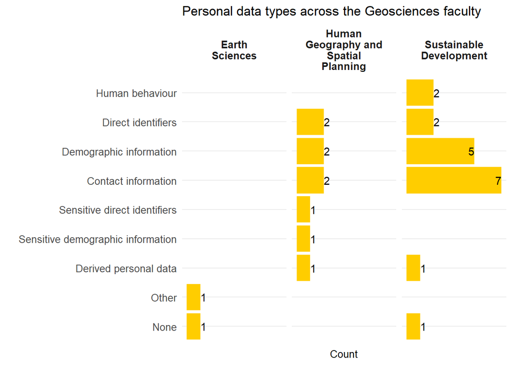

## Current practices

The first part of the survey addressed the researchers’ current practices in handling personal data in their research.

### Organisational and technical measures

#### University-wide results

With respect to organisational and technical measures used to handle personal data, most respondents indicated that they pseudonymise/anonymise their data. As this question is self-reported, we cannot assess whether the researchers’ data was actually sufficiently pseudonymised/anonymised in line with the GDPR. Secondly, many researchers seemed to implement access control and encryption, and complete a Data Management Plan (DMP) during their project(s). This is to be expected, as most funders nowadays require a DMP and many DMP templates explicitly address topics like pseudonymisation, access control and encryption. On the other hand, GDPR-specific assessments such as Data Protection Impact Assessments (DPIAs) or privacy reviews were least used - as it stands, these assessments are still only carried out on a case-by-case basis.

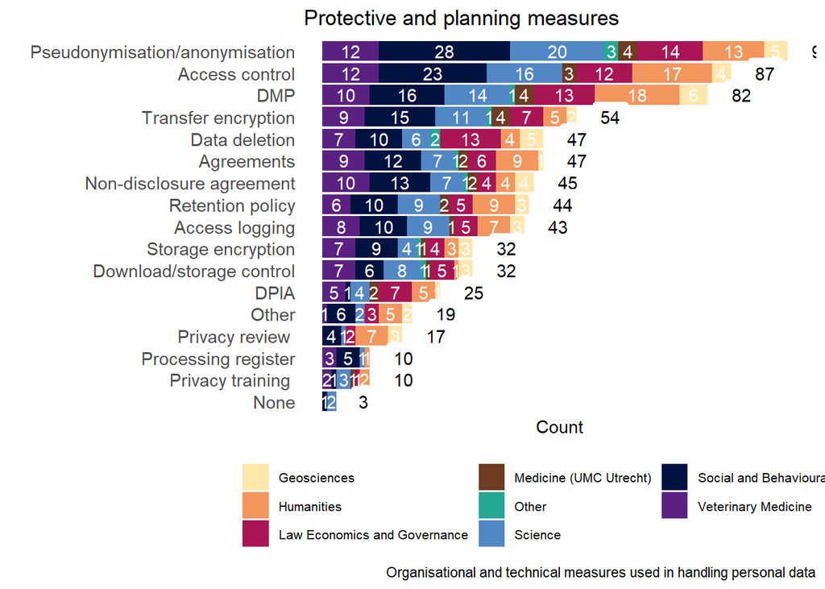

### Storage media used

#### University-wide results

When working with personal data, it is important to choose a sufficiently secure storage medium. Luckily, most respondents indicated to rely on storage solutions that are provided or recommended by UU - and in most cases are indeed safe for storing personal data. Nonetheless, some respondents indicated to use non-UU solutions, including cloud solutions that UU advises against using. Several respondents also indicated that they use other storage solutions, such as those of external institutions (e.g., University Medical Center, Trimbos Institute, Central Bureau of Statistics) and repositories (e.g., DANS EASY, CLARIAH).

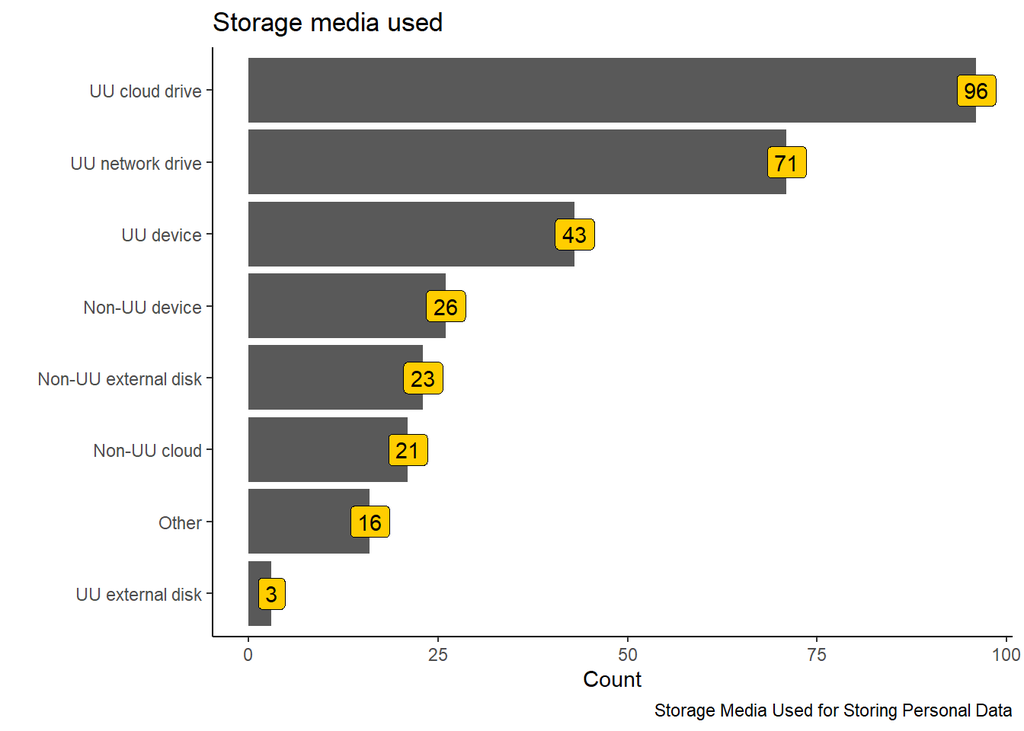

#### University-wide results

Consent is currently the legal basis most often used in researcher performed at UU. Luckily, only a small number of respondents indicated that consent forms are not applicable to their research or they don’t know what they are. The consent forms most often used seem to be approved by privacy officers or ethical committees. Some respondents however indicated to independently create and use consent forms. A handful of respondents indicated to use templates from external institutions, or no templates at all (e.g., because they use verbal consent or data from another party).

The mere fact that researchers make use of a consent form and information letter of course does not mean these forms are of sufficient quality. Therefore, we asked respondents what they typically include in their information to participants. Most respondents indicated to provide at least the basic information on the purposes for data collection and which data will be be used. Information on the data subjects’ rights and safeguards are often included as well.

Information and consent on data sharing and reuse is apparently not included as often. This is a point of concern, because not obtaining consent for sharing personal data for reuse may mean that data collected for a specific research project may not be reused again, reducing the scientific value of the data.

Finally, contact details of the Data Protection Officer (DPO) are not always included either, whereas these always have to be provided when working with personal data ([art. 13](https://gdpr-info.eu/art-13-gdpr/))

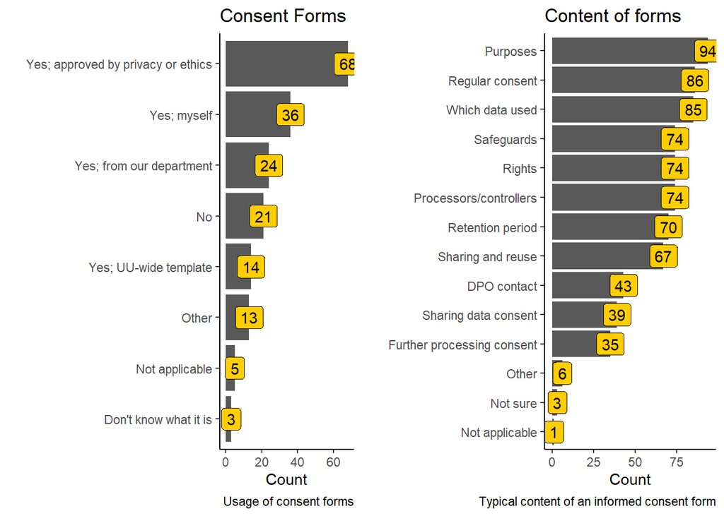

### Data Protection Impact Assessment (DPIA)

#### University-wide results

A Data Protection Impact Assessment (DPIA) is a legal instrument to assess the risks involved for data subjects, and helps determine the necessary safeguards to reduce those risks to an acceptable level. Despite it being an important legal instrument, most respondents indicated to never have carried one out, or heard of it, for that matter. A minority of the sample had heard of it, or has completed one. Currrently, the desired scenario is that researchers get help from a privacy officer when performing a DPIA, and the results seem to indicate that this is indeed the case in the majority of cases.

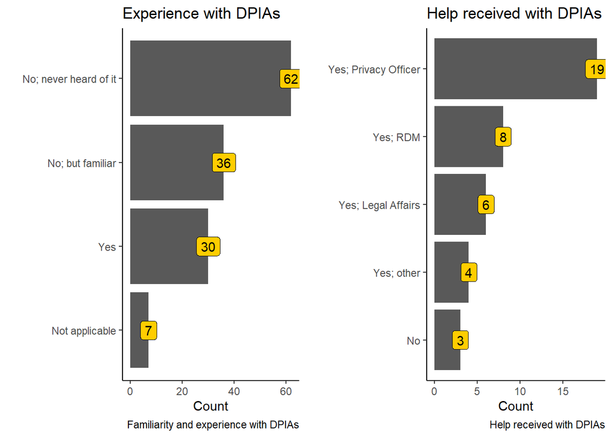

### Data sharing practices

#### University-wide results

To investigate how often data are being shared and under which circumstances, we asked respondents if and with which parties they typically share their research data, and which measures they usually take to do so securely. While there were some respondents who indicated not to share their data at all, most respondents seem to only share research data within the organisation, and otherwise within the European Economic Area (EEA). This is relatively good news, as such transfers usually require little, if any, additional safeguards. Responses in the “Other” category, however, suggest that a lot of data actually are shared, for example with co-authors at another institution, students, or in “pseudonymised form”.

Concerning the measures used before sharing data, most repondents indicated to pseudonymise their data, though we cannot assess the quality of such pseudonymisation. Researchers also seemed to use approved tools, agreements, and providing access without data transfer. Only a few respondents indicated that they involved a data expert while transferring data, and the use of Standard Contractual Clauses appears limited.

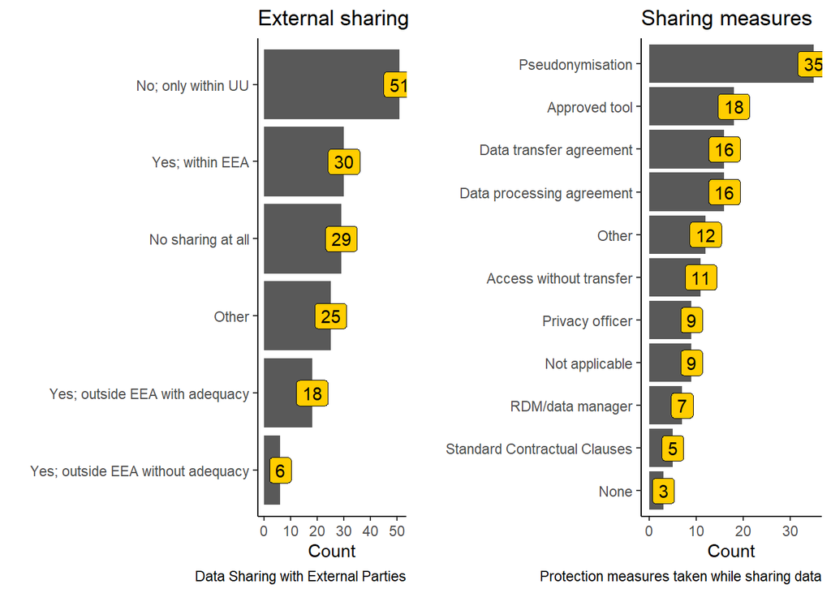

### Data publishing

#### University-wide

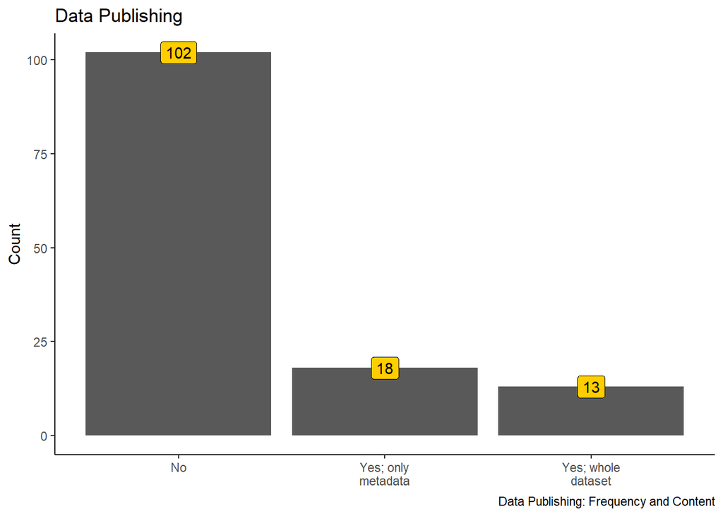

Open science and privacy are often seen as conflicting, as sharing personal data cannot be done just like that, but requires at the very least a valid legal basis and additional safeguards. Therefore, in our experience, to date not many datasets that contain personal data are shared for reuse purposes, and the survey respondents seemed to confirm this experience, as the majority of the respondents indicated not to publish their data, or only in anonymised form (again, we cannot be certain whether the data were indeed entirely anonymised).

The primary reason for not publishing data appears to be that researchers were still working on the data, they don’t want to/need to publish their data, or they cannot anonymise the data. Other reasons given by the respondents included that publishing data is too much effort, publication is undesirable, or just not considered.

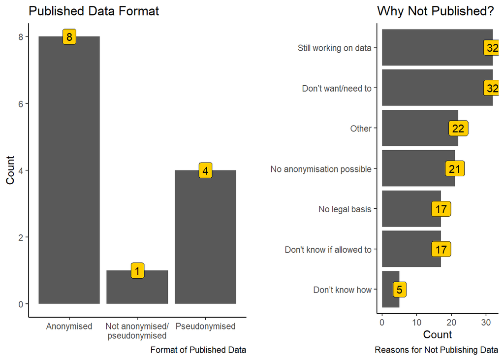

## Existing support channels

The second part of the survey concerned the visibility and use of existing support channels.

### Faculty privacy officer

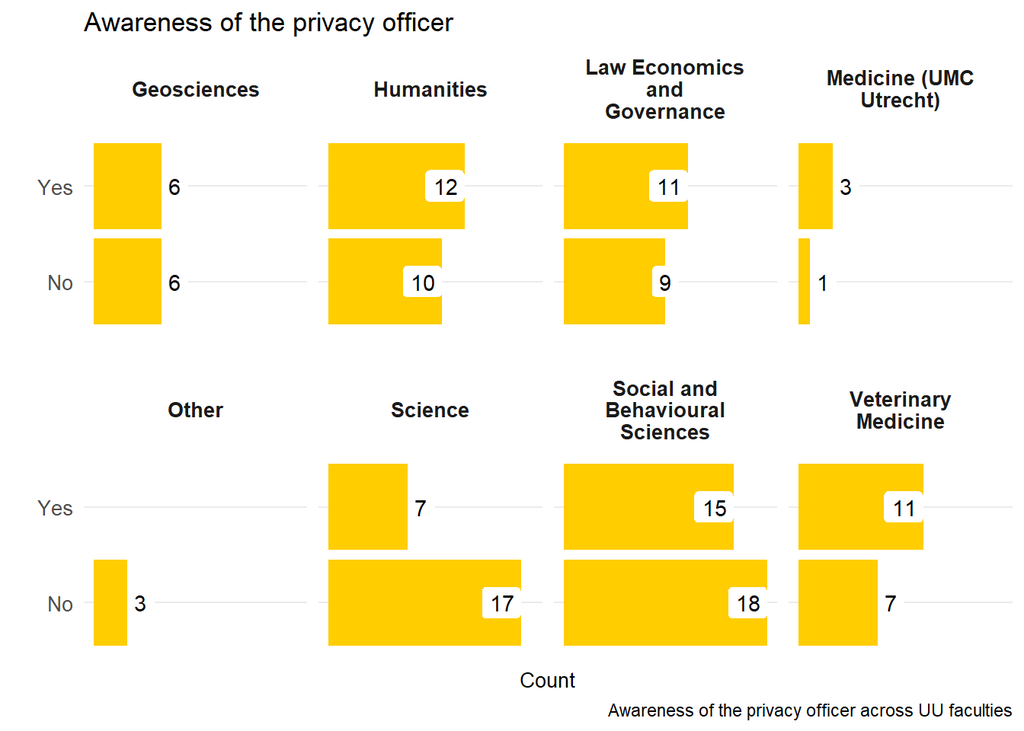

### Looking for help

#### University-wide

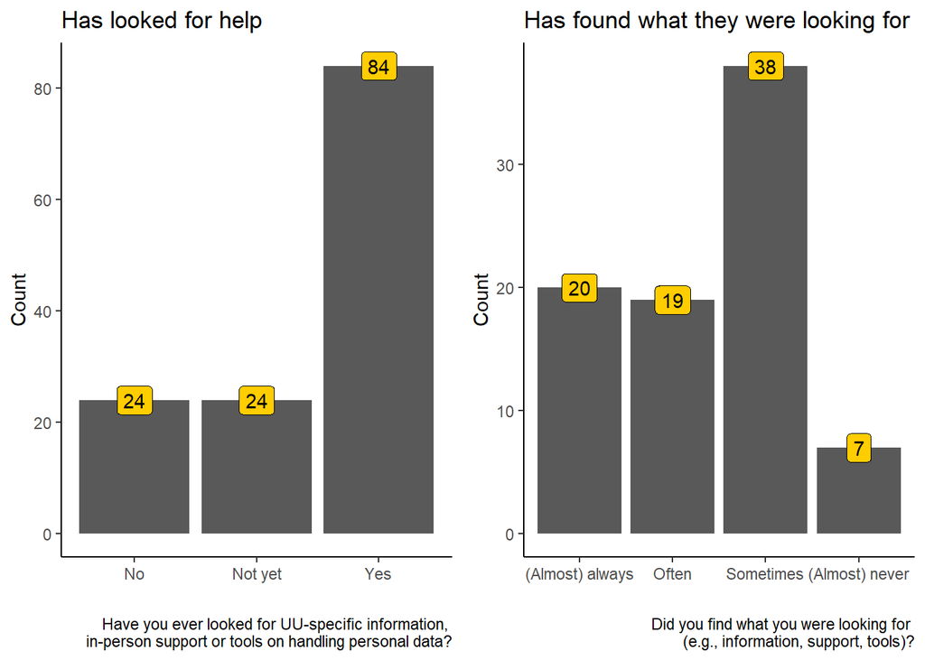

### Channels used to find support

#### University-wide

The graph below indicates which channels respondents used most when looking for information about handling personal data. Note that this was a multiple choice question, and so the numbers do no add up to the total number of survey respondents. As shown below, all sources mentioned were to some extent consulted by the respondents. However, there is large differentiation between these sources. The university website and intranet are the most visited online resources for information about handling personal data. Notably, colleagues appear to play an important role as well in informing researchers about how to handle personal data. This suggests that the better informed researchers are, the more positive the effect is on their colleagues as well. Moreover, this also suggests that in-person support may be a more effective way of increasing awareness of privacy-related practices than more “distant” information sources.

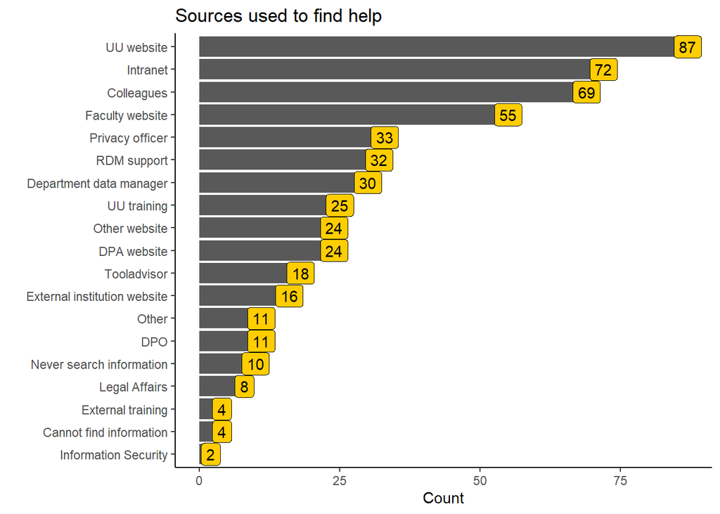

## Challenges and needs (survey)

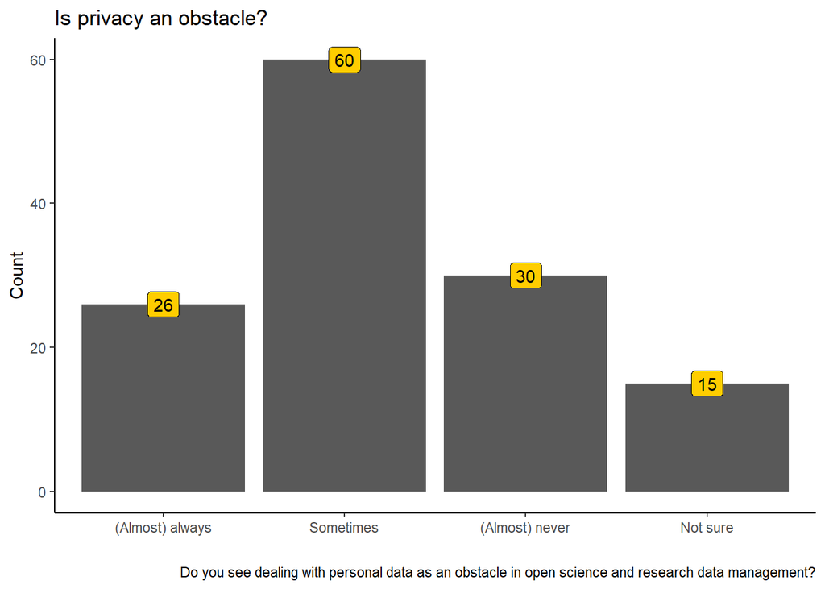

As can be seen above, most researchers experience privacy to be an obstacle for open science and research data management in some way. It is therefore important to aim for support in this area. What this support should look like, however, differs a bit. As can be seen below, accessible information and visible support channels seem to be the most wanted improvements in the current support, closely followed by UU-wide policy on the topic, and privacy-related walk-in hours.

How can we improve personal data-related services?

| bettersupport | Count | Percentage |
| --- | --- | --- |
| Information | 76 | 43.4 |
| Support visibility | 66 | 37.7 |
| UU-wide policy | 46 | 26.3 |
| Walk-ins | 34 | 19.4 |
| Workshops | 29 | 16.6 |
| Other | 27 | 15.4 |
| Support availability | 25 | 14.3 |
| Trainings | 24 | 13.7 |
| Tooling | 24 | 13.7 |

## Challenges and needs (open questions, meetings)

As mentioned in the Methods section, the responses on the following open questions, and the notes taken during the one-on-one meetings with researchers were coded to allow for easier analysis. From the survey, the following questions were coded:

- “Which challenges concerning the handling of personal data do you run into most often?”
- “What specific **information** or **tools** about handling personal data are you missing from existing sources?”
- “What can we do better to support you in handling personal data in research?” (responses to the “Other” option)

The codes that were assigned in both the survey and the meeting notes can be seen in the word cloud below: the larger the font, the more often the code was assigned. The meaning of each code is explained in the file “codes-freq_survey_meetings.csv” and below. Please note that there is overlap in respondents between the open questions in the survey and the meeting notes, and therefore some codes may have been applied twice for the same researcher.

[interactive chart not shown]

**Below we go into the most frequently mentioned challenges/needs expressed by researchers in the survey (open questions) and one-one-one meetings:**

### Visibility and findability

It should be clear where to go for help (to whom or which webpage, etc.) (mentioned 27 times). Some respondents indicated not to know where to go for help with privacy-related matters, others mentioned that there should be *more* support personnel available (8). One researcher said to prefer having one place to go to for all data-related questions. As a matter of fact, many faculties have such a “one-stop-shop” in place, but responses such as these indicate that their visibility may be improved.

Closely related to visibility is findability. Many researchers point out that available information is difficult to find, or it is confusing which source should be followed. As an example, one researcher from the faculty of Humanities was determined that they found some useful information at the RDM Support website. However, upon closer inspection, it appeared that this information arose from another data management-related website with the UU logo on it.

> “UU biedt ontzettend veel aan, maar je moet veel websites bezoeken om alles te vinden […] Een duidelijk overzicht voor welke informatie je waar moet zijn zou fijn zijn.”

### Hands-on support

Many (23) researchers indicated that support staff could sometimes provide support in a more hands-on fashion, rather than abstract advice and telling researchers how *not* to do things. Some researchers added that privacy professionals sometimes have a tendency to cling to the letter of the law, leading to significant delays in their project, instead of looking at how to concretely solve existing issues in practice (mentioned 10 times):

> “Soms zijn we door deze regels heiliger dan de paus.”

> “Actual getting-your-hands-dirty support: not the kind that tells you what to do, but also the kind that helps you by doing.”

### Less bureaucracy

Processes were often experienced as time-inefficient, and sometimes longer and more bureaucratic than necessary (mentioned by 21 researchers). For example, the DPIA process was mentioned explicitly (9 times), as well as having to fill out too many forms with overlapping content (e.g., Privacy Scan, Data Management Plan, DPIA). Some (9) researchers argued that (part of) this burden should be relieved or carried by support staff:

> “Minder acties die gericht zijn op inhoudelijk trainen van WP en meer uit handen nemen van deze groep.”

> “Sharing data costs a lot of time and is inefficient when you do not do it often”

### Unclear processes and guidelines

Many (18) researchers complained that it was unclear what was expected of them when they processed personal data in their research, or that they would like to have more, or more practical guidelines (14) on this topic, for example on:

- What steps do researchers need to take? (3)
- Who should researcher ask for help in which situation?
- Who is responsible or has the authority to make the right decisions when handling personal data? Do privacy officers/DPO have to be seen as gatekeepers (similar to an ethical committee) or as advisers? Do researchers have to listen to the advise, or is that their own responsibility? (4)
- When rules change, how does that affect what researchers need to do? (1)
- Different processes for different types of research (e.g., student projects vs. large longitudinal projects, 3)

### Information and education

A large part of the respondents expressed a need for more (clear) information and education with respect to handling personal data in research. In general, researchers indicated that the information offered to them should be more clear (3), simpler 9, consistent across resources (8), possibly in the form of templates (14). Luckily, some researchers indicated to already be happy with existing materials (4).

#### Information for specific research or data types

Many researchers indicated to have a need for more tailored information for specific types of data or research (9), for example for etnographic data (2), historical data (2), or video data (3).

> “De informatie is gewoon veel te generiek, er zouden templates moeten zijn per type onderzoek.”

> “Veel templates en uitlegmodellen spreken over data, data packages en metadata, maar die woorden zijn niet ingebed in historisch onderzoek. Er ontstaat al snel verwarring over wat historici nu precies moeten met archiefmateriaal in het licht van privacy.”

#### Frequently asked questions

A selection of researchers used the space in the open questions and/or the meetings to ask knowledge-related questions. These can be used in future support efforts, such as the [Data Privacy Handbook](https://utrechtuniversity.github.io/dataprivacyhandbook), future courses, or other future information campaigns to better address researchers’ needs. Below are examples of the most commonly asked questions:

- When are data still personal (9), how to anonymise data (3), and when are data anonymised sufficiently (5)?
- What are the privacy-related requirements for students? (7)
- How to store different types of personal data? (6)
- Data sharing: what data can be shared and with whom? (7)
- How to find a balance between informing data subjects too little vs. providing too much privacy-related information that will scare them off or hurt their trust in research? (5)
- How to balance open science and privacy? (5). Related: when is reusing data fir different purposes allowed? (e.g., education data, data collected by students, 4)
- How to collaborate with multiple institutions? (4)

#### Education and onboarding

The need for more educational resources was also recognised by a selection of the respondents. Concretely, researchers could be educated more in the following ways:

- Privacy and/or research data management as part of the master or PhD curriculum (8)
- Privacy as part of the onboarding procedure of new employees (5)
- Mandatory privacy training for supervisors, principal investigators, professors, and/or teachers (4)
- A course on how to handle personal data in research (2)

> “There is no one who tells at the start of your PhD how you should handle your data. […] I think new PhD students should get a basic course on data management and privacy.”

### … or simply no issues

Notably, there were also researchers who indicated **not** to have run into issues (yet), or to have received sufficient and useful help (9). For example:

> “The data manager and privacy officer of the faculty of humanities help a lot. This support is essential!”

> “Tot nu toe heb ik niet veel problemen gehad. De institutional review board van onze afdeling kijkt altijd kritisch naar de onderzoeksvoorstellen, ook met name op omgaan met persoonsgegevens.”

# Conclusion

This report summarised the findings of the Data Privacy Survey and subsequent one-on-one meetings with researchers. Our aim was to investigate the current practices, challenges and needs of Utrecht University (UU) researchers in the handling of personal data.

## Results summary

In short, we have found that:

- Personal data are processed in each faculty and across all academic positions at Utrecht University, but mostly among the faculties of Science and Social and Behavioural Sciences, and among early-career researchers.
- Most researchers deal with tabular, textual, code, and audiovisual data, which contain mainly demographics, contact information, and direct identifiers.
- Most researchers seem to be at least familiar with concepts like anonymisation and pseudonymisation, access control, and UU-approved tools for handling personal data. However, the knowledge level differs quite a bit. For example:
  - some researchers seem to store data on locations that officially are not allowed.
  - information to study participants is sometimes lacking all the required information, such as contact information from the Data Protection Officer, and information and consent for sharing data for reuse purposes.
  - about half of the sample is not familiar with the concept of a Data Protection Impact Assessment.
  - data are often shared, but not all the right measures are always taken to do so securely.
- Privacy is sometimes found to be an obstable for open science, also confirmed by a relatively low amount of published datasets.
- Not all help is found equally well. For example, about half of the respondents indicated not to be aware of their faculty privacy officer, and many researchers resort to the UU website, intranet, and colleagues for help.
- Researchers may benefit from greater visibility and findability of support, specific tools. more and more hands-on support, more clear and less bureaucratic processes and guidelines, and specific information and education.

Together, these findings suggest that there is still a lot to be gained regarding awareness and secure practices in scientific research with personal data.

## Recommendations

### Increased visibility and findability

The findings show that the visibility of existing support for handling personal data can be increased at UU. This includes visibility of privacy officers, legal affairs and Research Data Management Support, as well as faculty- or department-level support.

As shown by the fact that many respondents consult with colleagues for information and support, personal contact with supporters will likely be more effective at increasing awareness and uptake of secure privacy practices than a passive website that may not always answer all possible questions.

Some suggestions for increasing visibility and findability:

- Make sure there is (sufficient) support available to help researchers in time. If there is no support available, the odds are that researchers may not ask for help at all and thus forget important privacy elements in the design of their research project.
- Make sure support staff are easy to find. For example, give them a clear location on the university website and/or on the intranet. Also indicate who is available for what type of support and for which target audience (e.g., “all UU researchers”, “employees from the Faculty of Humanities”, etc.)
- Make sure information on handling personal data in research is easy to find. The UU website and intranet seem the most suitable places, as these are the most visited to look for information according to the survey.
- Make researchers actively aware of existing support channels. For example, first-line support can visit important faculty or department events, offer to give a workshop, and keep short lines of contact with department heads.

### More hands-on support

In line with the findings described above, more hands-on support is desirable. This can for example be reached by:

- More collaboration between different types of data support. For example, at UU there is a clear distinction between privacy officers (employed by faculties), data managers (employed by the University Library and some faculties), information security officers (Information Technology Services) and research engineers (Information Technology Services). However, in practice there is often overlap between either or all of these positions. Regular collaboration between these parties can:
  - help privacy and security experts understand the perspective of the researcher and possibly how to apply their advice in practice,
  - help data managers and research engineers understand the GDPR requirements and translate those to practice, and
  - enable reuse of solutions already applied in earlier cases that either party may not be aware of.
- Together with researchers, developing suitable practical solutions (tools, protocols, etc.) for specific scenarios and/or types of research, and sharing them with the world for reuse (if possible).
- Increasing contact between support staff and researchers to understand the issues they are dealing with that require a solution.

### Decreased administrative burden

In line with the findings described above, it is desirable to attempt to decrease the administrative burden on researchers. We suggest that the bureaucracy issues can be partly attributed to:

1. Understaffing: it is currently difficult for data support staff to review *all* research projects involving personal data at UU. This can lead to projects with issues being noticed too late and researchers having to make changes to their project after the fact. This creates unnecessary administrative burden that could have been prevented had researchers been in contact with support staff from early on.
2. Lack of unifying policy on steps to take when working with personal data: At the moment each faculty has its own procedure, or has none at all. This can create confusion among both researchers and support staff on which steps to take when, who to contact for help, or who is responsible for deciding on compliance.
3. Lack of integration between systems and staff: having to fill out the same thing multiple times may be caused by the fact that different administrative systems are used for different purposes. Integration of these systems may lead to a relief of the administrative burden experienced by researchers.  
   For example, DMPonline is used at UU for registering Data Management Plans. However, DMP templates do not include sufficient questions about how personal data are handled, and thus a privacy scan may be additionally required. Privacy is sometimes part of an ethical application, and so this same information may be included there again as well. Finally, the processing register also requires information on (among others) the type and sensitivity of personal data, which is a third system where this information will be registered.

### Education and outreach

Many problems seem to arise from the fact that privacy has not been taken into account from the design phase of a research project. This leads to research support staff being contacted too late in the process, who then has to tell the researcher to retrospectively make changes in their design in order to move forward. Such scenarios may be prevented by, for example:

- Including the basic of handling personal data and contact details of support staff in onboarding processes when researchers are newly hired.
- Educating researchers on taking privacy into account in the designing phase of their project.
- Organising outreach events, such as the “Privacy and Security week” making researchers aware of privacy-related measures (see further Visibility).
- Embedding privacy in existing materials and processes, such as in ethical applications, in the education of research master and PhD students, etc.

### Specific information and tools

The specific information and tools described above can be addressed in current and future support efforts. One of these is the [Data Privacy Project](https://utrechtuniversity.github.io/dataprivacyproject), from which this Data Privacy Survey forms a part. Other efforts may include the updating of websites from RDM Support, faculties, or ethical committees, and the updating of services offered by the IT department.

## Discussion

In order to interpret the results described in this report correctly, there are a few matters that need to be taken into account:

1. The respondents of the survey represented only a small selection of all of UU’s Scientific Personnel. Therefore, the results presented here should not be overgeneralised to represent all of UU’s researchers. It is likely that at least part of the respondents had a specific reason to do so. For example, they may have explicitly wanted to raise their voice because of some bad experiences they had. Although it is important that these concerns be heard, they should not be interpreted as to speak for all UU researchers.
2. It is important to note that we, the writers of this report, cannot be considered fully objective in interpreting the survey results. The feedback received via this survey also involves our own services and possibly work performance. Although we have attempted to interpret the results of the survey without bias, it is possible that we have indeed introduced some, especially where the open questions and one-on-one meetings are concerned.
3. The questions in this survey intentionally do not address at which data support personnel the feedback is targeted. This also means that our recommendations do not specify Who within the organisation should pick them up. Preferably, these recommendations will be picked up by a collaboration between data support at different levels of the organisation (departmental, faculty, central) and, if needed, beyond, to address researchers’ concerns and improve the support surrounding the handling of personal data in research.

# Technical information

[^1]: The Data Privacy Project is funded by Utrecht University’s Research IT program and a Digital Competence Center grant from the Dutch Organization for Scientific Research (NWO). It is led by Utrecht University’s [Research Data Management Support](https://uu.nl/rdm/), in collaboration with the University Library, Information Technology Services, first- and second-line privacy officers, information security, and others.